# Project Business Statistics: E-news Express

**Marks: 60**

## Define Problem Statement and Objectives

E-news Express, an online news portal, aims to expand its business by acquiring new subscribers. The design team of the company has researched and created a new landing page that has a new outline & more relevant content shown compared to the old page. In order to test the effectiveness of the new landing page in gathering new subscribers, the Data Science team conducted an experiment by randomly selecting 100 users and dividing them equally into two groups.

The objective is to explore the data and perform a statistical analysis (at a significance level of 5%) to determine the effectiveness of the new landing page in gathering new subscribers for the news portal by answering the following questions:

- Do the users spend more time on the new landing page than on the existing landing page?
- Is the conversion rate (the proportion of users who visit the landing page and get converted) for the new page greater than the conversion rate for the old page?
- Does the converted status depend on the preferred language?
- Is the time spent on the new page the same for the different language users?

## Import all the necessary libraries

```python
import pandas as pd
import numpy as np
import matplotlib.pyplot as plt
import seaborn as sns
%matplotlib inline
import scipy.stats as stats
```

## Reading the Data into a DataFrame

```python
data = pd.read_csv('abtest.csv')
```

```python
df= data.copy()
```

## Explore the dataset and extract insights using Exploratory Data Analysis

- Data Overview
  - Viewing the first and last few rows of the dataset
  - Checking the shape of the dataset
  - Getting the statistical summary for the variables
- Check for missing values
- Check for duplicates

```python
#populating first few rows of the dataset
df.head()
```

|  | user_id | group | landing_page | time_spent_on_the_page | converted | language_preferred |
| --- | --- | --- | --- | --- | --- | --- |
| 0 | 546592 | control | old | 3.48 | no | Spanish |
| 1 | 546468 | treatment | new | 7.13 | yes | English |
| 2 | 546462 | treatment | new | 4.40 | no | Spanish |
| 3 | 546567 | control | old | 3.02 | no | French |
| 4 | 546459 | treatment | new | 4.75 | yes | Spanish |

```python
#populating last few rows of the dataset

df.tail()
```

|  | user_id | group | landing_page | time_spent_on_the_page | converted | language_preferred |
| --- | --- | --- | --- | --- | --- | --- |
| 95 | 546446 | treatment | new | 5.15 | no | Spanish |
| 96 | 546544 | control | old | 6.52 | yes | English |
| 97 | 546472 | treatment | new | 7.07 | yes | Spanish |
| 98 | 546481 | treatment | new | 6.20 | yes | Spanish |
| 99 | 546483 | treatment | new | 5.86 | yes | English |

```python
#running the info function to check the data types of the columns for the dataset
df.info()
```

```
<class 'pandas.core.frame.DataFrame'>
RangeIndex: 100 entries, 0 to 99
Data columns (total 6 columns):
 #   Column                  Non-Null Count  Dtype
---  ------                  --------------  -----
 0   user_id                 100 non-null    int64
 1   group                   100 non-null    object
 2   landing_page            100 non-null    object
 3   time_spent_on_the_page  100 non-null    float64
 4   converted               100 non-null    object
 5   language_preferred      100 non-null    object
dtypes: float64(1), int64(1), object(4)
memory usage: 4.8+ KB
```

There are 100 non-null entries for each of the 6 columns, with 4 categorical variables including group, landing_page, converted and language_preferred and 2 numerical variables including user_id and time_spent_on_the_page.

```python
#running the decribe function to get a statistical summary of the dataset
df.describe()
```

|  | user_id | time_spent_on_the_page |
| --- | --- | --- |
| count | 100.000000 | 100.000000 |
| mean | 546517.000000 | 5.377800 |
| std | 52.295779 | 2.378166 |
| min | 546443.000000 | 0.190000 |
| 25% | 546467.750000 | 3.880000 |
| 50% | 546492.500000 | 5.415000 |
| 75% | 546567.250000 | 7.022500 |
| max | 546592.000000 | 10.710000 |

```python
#Running the shape method to check the shape of the dataset
df.shape
```

```
(100, 6)
```

The sample data contains 100 data points for each of the 6 columns in the dataset

```python
#Checking missing values in the dataset

df.isna().sum()
```

```
user_id                   0
group                     0
landing_page              0
time_spent_on_the_page    0
converted                 0
language_preferred        0
dtype: int64
```

There are no missing values in any of the column

```python
#Checking for duplicates

df['user_id'].apply(type).value_counts()
df['group'].apply(type).value_counts()
df['landing_page'].apply(type).value_counts()
df['time_spent_on_the_page'].apply(type).value_counts()
df['converted'].apply(type).value_counts()
df['language_preferred'].apply(type).value_counts()
```

```
<class 'str'>    100
Name: language_preferred, dtype: int64
```

```python
df.duplicated().sum()
```

```
0
```

There are no duplicate entries in the dataset.

### Univariate Analysis

```python
#Analyzing individual categorical variables by using value_counts()

df['group'].value_counts()
```

```
control      50
treatment    50
Name: group, dtype: int64
```

```python
#Analyzing individual categorical variables by using value_counts()
df['landing_page'].value_counts()
```

```
old    50
new    50
Name: landing_page, dtype: int64
```

```python
#Analyzing individual categorical variables by using value_counts()
df['converted'].value_counts()
```

```
yes    54
no     46
Name: converted, dtype: int64
```

```python
#Analyzing individual categorical variables by using value_counts()
df['language_preferred'].value_counts()
```

```
Spanish    34
French     34
English    32
Name: language_preferred, dtype: int64
```

- There are equally divided users in control and treatment groups.
- In line with the groups, the count of users are equally divided also for the old and new landing pages.
- Overall, converted users are higher than non-converted.
- There are three distinct languages including Spanish, French and English with almost equal number of users.

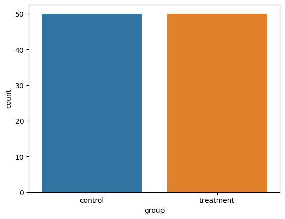

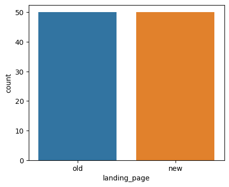

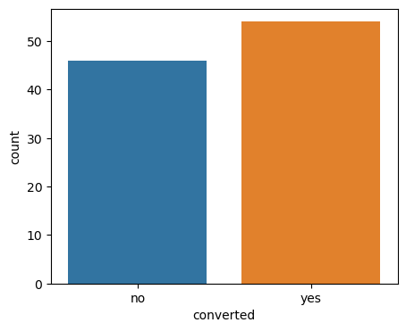

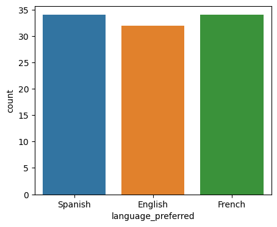

```python
#Plotting the categorical variables including group, landing_page, converted, language_preferred using sns.countplot
sns.countplot(x=df['group'])

plt.figure(figsize=(5,4))
sns.countplot(x=df['landing_page'])

plt.figure(figsize=(5,4))
sns.countplot(x=df['converted'])

plt.figure(figsize=(5,4))
sns.countplot(x=df['language_preferred'])
```

From the above categorical varaible countplots, it can be observed that:

- Groups of users are equally divided between control and treatment groups
- In line with the equally divided groups, the numbers of users of old and new landing page are also equally divided
- The converted users overall seem to be higher than the non-converted users.
- Three different languages are preferred by users including English, French and Spanish.
- Count of users preferring Spanish and French are equal with 34 users, where as English is preferred by 32 users.

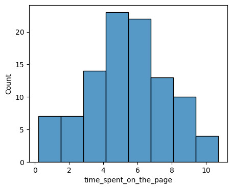

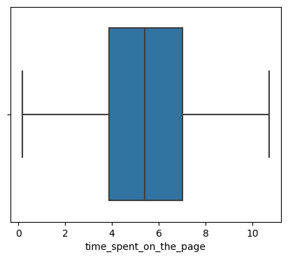

```python
#Plotting the numerical variable - time_spent_on_the_page using a histplot and boxplot functions from seaborn
plt.figure(figsize=(5,4))
sns.histplot(data=df,x='time_spent_on_the_page')
plt.show()
plt.figure(figsize=(5,4))
sns.boxplot(data=df,x='time_spent_on_the_page')
plt.show()
```

- Time_spent_on_the_page has an approximately symmerical distribution.
- Overall, the time spent by all users including both control and treatment group users ranges from ~0.2 mins to ~ 10 mins.

### Bivariate Analysis

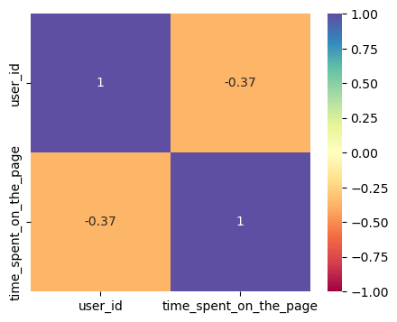

```python
#performing a correlation analysis on the dataset

plt.figure(figsize=(5,4))
sns.heatmap(df.corr(),annot=True,cmap='Spectral',vmin=-1,vmax=1)
plt.show()
```

- No conclusion can be drawn from the correlation performed above, as the dataset does not have enough numerical variables. User_Ids are only present for count of user infromation.

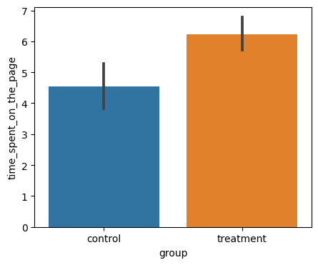

```python
#Plotting a barplot of group and time_spent_on_the_page

plt.figure(figsize=(5,4))
sns.barplot(data=df,x=df['group'],y=df['time_spent_on_the_page'])
```

- From the above barplot, it can be concluded that the time spent by the treatment group users is much higher than the control group.

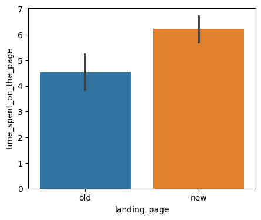

```python
#Plotting a barplot of landing page and time_spent_on_the_page

plt.figure(figsize=(5,4))
sns.barplot(data=df,x=df['landing_page'],y=df['time_spent_on_the_page'])
```

- Similar to the previous barplot, it can be concluded that the time spent on the new landing page is much higher than the old landing page.

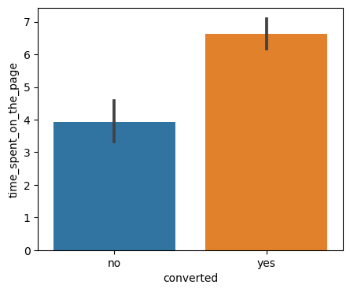

```python
#Plotting a barplot of converted and time_spent_on_the_page

plt.figure(figsize=(5,4))
sns.barplot(data=df,x=df['converted'],y=df['time_spent_on_the_page'])
```

```python
#Grouping to compute the overall time spent by both converted and non-converted users
df.groupby(['converted'])['time_spent_on_the_page'].sum()
```

```
converted
no     180.13
yes    357.65
Name: time_spent_on_the_page, dtype: float64
```

- Converted users overall spend a higher time than the non-converted users.

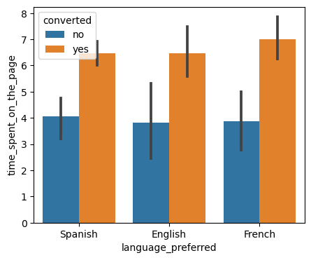

```python
#Plotting a barplot of converted and time_spent_on_the_page

plt.figure(figsize=(5,4))
sns.barplot(data=df,x=df['language_preferred'],y=df['time_spent_on_the_page'],hue=df['converted'])
```

- There seems to be no difference in the time spent by non-converted users irrespective of the language preferred.
- Among the converted users, highest amount of time is spent by French language preferred user.

```python
#Computing the average time spent by users preferring different languages
df.groupby([df['language_preferred']])['time_spent_on_the_page'].mean()
```

```
language_preferred
English    5.559062
French     5.253235
Spanish    5.331765
Name: time_spent_on_the_page, dtype: float64
```

- There is not much difference in the average time spent by English, Spanish or French language users.

```python
#Creating a separate data frame for the users of the old landing page
df_old = df[df['landing_page']=='old']
df_old.head()
```

|  | user_id | group | landing_page | time_spent_on_the_page | converted | language_preferred |
| --- | --- | --- | --- | --- | --- | --- |
| 0 | 546592 | control | old | 3.48 | no | Spanish |
| 3 | 546567 | control | old | 3.02 | no | French |
| 5 | 546558 | control | old | 5.28 | yes | English |
| 7 | 546581 | control | old | 6.53 | yes | Spanish |
| 9 | 546548 | control | old | 2.08 | no | English |

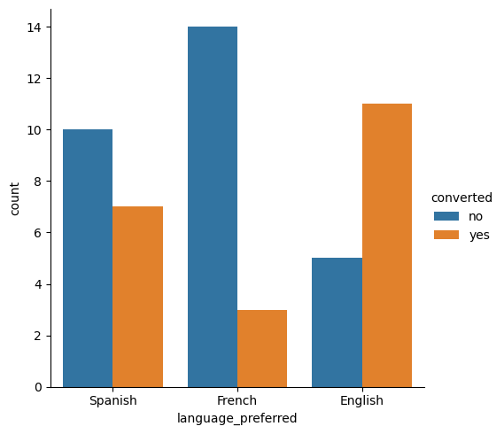

```python
#Plotting the language preferred for converted users on the old landing page
plt.figure(figsize=(5,4))
sns.catplot(data=df_old, x='language_preferred',hue='converted',kind='count')
```

- Non-converted users on the old landing page have French as the most preferred language followed by Spanish.
- Most of the converted users on the old landing page prefer English language followed by Spanish.
- French is the least preferred language by converted users on the old landing page.

```python
#Creating a separate data frame for the users of the new landing page
df_new = df[df['landing_page']=='new']
df_new.head()
```

|  | user_id | group | landing_page | time_spent_on_the_page | converted | language_preferred |
| --- | --- | --- | --- | --- | --- | --- |
| 1 | 546468 | treatment | new | 7.13 | yes | English |
| 2 | 546462 | treatment | new | 4.40 | no | Spanish |
| 4 | 546459 | treatment | new | 4.75 | yes | Spanish |
| 6 | 546448 | treatment | new | 5.25 | yes | French |
| 8 | 546461 | treatment | new | 10.71 | yes | French |

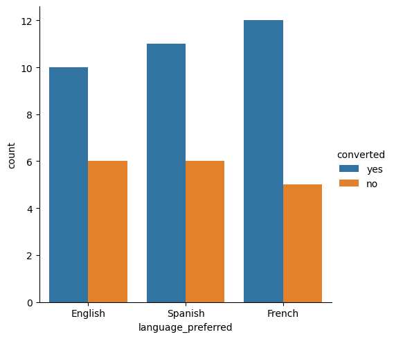

```python
#Plotting the language preferred for converted users on the new landing page
plt.figure(figsize=(5,4))
sns.catplot(data=df_new, x='language_preferred',hue='converted',kind='count')
```

- Converted users on the new landing page mostly prefer French, followed by Spanish and then English.
- Non-converted users preferring English and Spanish are almost the same on the new landing page.

## 1. Do the users spend more time on the new landing page than the existing landing page?

### Perform Visual Analysis

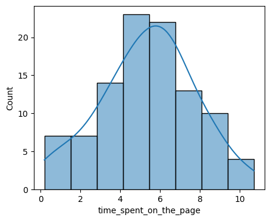

```python
#Plotting an histogram of the overall time spent by all users on the two landing pages
plt.figure(figsize=(5,4))
sns.histplot(x=df['time_spent_on_the_page'],kde=True)
```

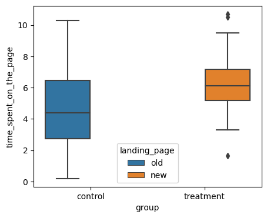

```python
#plotting a boxplot of the two groups with the time spent on their respective landing pages
plt.figure(figsize=(5,4))
sns.boxplot(x=df['group'],y=df['time_spent_on_the_page'],hue=df['landing_page'])
```

```python
#Grouping time spent by users on the two landing pages
df.groupby(['landing_page'])['time_spent_on_the_page'].sum()
```

```
landing_page
new    311.16
old    226.62
Name: time_spent_on_the_page, dtype: float64
```

```python
#Computing the mean time spent by converted users
df.groupby(['converted'])['time_spent_on_the_page'].mean()
```

```
converted
no     3.915870
yes    6.623148
Name: time_spent_on_the_page, dtype: float64
```

- Converted users spend an average of 6.6 mins on the two landing pages.

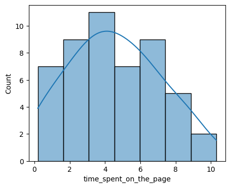

```python
#Plotting the time spent by users on the old landing page
plt.figure(figsize=(5,4))
sns.histplot(x=df_old['time_spent_on_the_page'],kde=True)
```

- The plot of time spent by users on the old landing page shows a slightly right skewed distirbution.

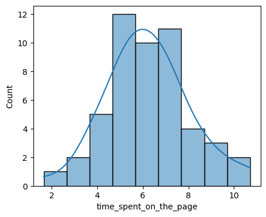

```python
#Plotting the time spent by users on the new landing page
plt.figure(figsize=(5,4))
sns.histplot(x=df_new['time_spent_on_the_page'],kde=True)
```

- The plot of time spent by users on the new landing page shows almost a symmetrical distirbution.

### Step 1: Define the null and alternate hypotheses

> $H_0$: Mean time users spend on new and old landing page is the same\ $H_a$: Mean time users spend on new landing page is more than old landing page

or

> $H_0:\mu_1=\mu_2$\ $H_a:\mu_1>\mu_2$

where $\mu_1$ is the mean time users spend on new landing page and $\mu_2$ is the mean time users spend on old landing page

### Step 2: Select Appropriate test

This is a case of two independent sample t-test for equality of means with unknown standard deviation, and we shall use ttest_ind(), since the data is divided into two equal groups. The existing landing page is served to the first group(control group) and the new landing page is served to the treatment group, without any overlap of users between the two groups. The following assumptions are full-filled:

1) Data is continous - Time spent on landing pages are continous.  
2) Normally distributed populations - Looking at the histogram, it can be interpreted that the distribution of the two samples are normal, also the sample size is greater than 30.  
3) Independent Populations - As we are taking random samples for two different groups, the two samples are from two independent populations.  
4) Unequal population standard deviations - As the sample standard deviations are different, the population standard deviations may assumed to be different.  
5) Random sampling from the population - Yes, we are informed that the collected sample a simple random sample.

### Step 3: Decide the significance level

Using a statistical significance level of 5%

### Step 4: Collect and prepare data

```python
#Computing the mean time of and sample standard deviations of users spent on the page
print('The mean time spent for control group is ' + str(round(df[df['group']=='control'].time_spent_on_the_page.mean(),1)) +' mins')
print('The mean time spent for treatment group is ' + str(round( df[df['group']=='treatment'].time_spent_on_the_page.mean(), 1))+' mins')
print('The standard deviation of time spent for control group is ' + str(round(df[df['group']=='control'].time_spent_on_the_page.std(),2)) +' mins')
print('The standard deviation of time spent for treatment group is ' + str(round(df[df['group']=='treatment'].time_spent_on_the_page.std(), 2))+' mins')
```

```
The mean time spent for control group is 4.5 mins
The mean time spent for treatment group is 6.2 mins
The standard deviation of time spent for control group is 2.58 mins
The standard deviation of time spent for treatment group is 1.82 mins
```

### Step 5: Calculate the p-value

```python
#importing ttest_ind() from scipy.stats

from scipy.stats import ttest_ind

#computing the test-statistic and p-value of ttest_ind()

test_statistic,p_value = ttest_ind(df_new['time_spent_on_the_page'],df_old['time_spent_on_the_page'],equal_var =False,alternative='greater')

print('The p-value is',p_value)
```

```
The p-value is 0.0001392381225166549
```

### Step 6: Compare the p-value with $\alpha$

- Since p_value of 0.00013 is less than the level of significance of 0.05 and hence we reject the null hypothesis.

### Step 7: Draw inference

- Based on the above p_value, we have enough evidence to conclude that the mean time users spend on new landing page is more than old landing page.

**A similar approach can be followed to answer the other questions.**

## 2. Is the conversion rate (the proportion of users who visit the landing page and get converted) for the new page greater than the conversion rate for the old page?

```python
#Using group by function to group converted users for both landing pages and calculating the counts for each
df.groupby(['converted'])['landing_page'].value_counts()
```

```
converted  landing_page
no         old             29
           new             17
yes        new             33
           old             21
Name: landing_page, dtype: int64
```

```python
#computing the percentage of converted users for the new landing page
df_new['converted'].value_counts(normalize=True)
```

```
yes    0.66
no     0.34
Name: converted, dtype: float64
```

```python
#computing the percentage of converted users for the old landing page

df_old['converted'].value_counts(normalize=True)
```

```
no     0.58
yes    0.42
Name: converted, dtype: float64
```

- Conversion rate of new and old landing page is 66% and 42% respectively.

```python
#Computing conversion rate based on language preferred for the new landing page
df_new.groupby(['language_preferred'])['converted'].value_counts(normalize=True)
```

```
language_preferred  converted
English             yes          0.625000
                    no           0.375000
French              yes          0.705882
                    no           0.294118
Spanish             yes          0.647059
                    no           0.352941
Name: converted, dtype: float64
```

- Conversion rate for the new landing page is higher for French (70%) and Spanish (64%) Language users followed by English language users (62%)

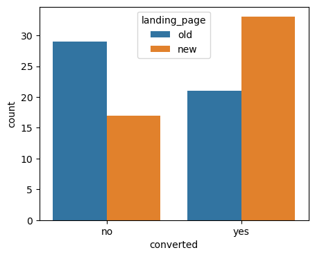

```python
#plotting converted users for both the landing pages
plt.figure(figsize=(5,4))
sns.countplot(x=df['converted'], hue=df['landing_page'])
```

The plot of conversion and landing page suggests that the treatment group users with access to new landing page are more likely to convert as compared to the control group users with access to the old landing page.

Using proportions z-test to test if conversion rate (the proportion of users who visit the landing page and get converted) for the new page greater than the conversion rate for the old page, with the following hypothesis:

> $H_0$: Proportion of users who visit new landing page (p1) = Proportion of users who visit old landing page (p2)\ $H_a$: Proportion of users who visit new landing page (p2) > Proportion of users who visit old landing page (p2)

or

> $H_0:p_1 = p_2$ $H_a:p_1 > p_2$

The assumptions of proportions z-test are also satisified as noted below:

- Binomally distributed population - Yes, a user is either converted or not converted.
- Random sampling from the population - Yes, we are informed that the collected sample is a random sample.
- Can the binomial distribution approximated to normal distribution - Yes. For binary data, Central Limit Theorem works slower than usual. Have further checked the standard if np and n(1-p) are greater than or equal to 10. Here, n and p refer to the sample size and sample proportion respectively.

  > $np_1 = 50\cdot \frac{33}{50} =33 \geq 10\\ n(1-p_1) = 50 \cdot \frac{50-33}{50} =17 \geq 10 \\ np_2 = 50\cdot \frac{21}{50} =21 \geq 10\\ n(1-p_2) = 50 \cdot \frac{50-21}{50} =29 \geq 10 $

```python
#importing proportions_ztest from statsmodels.stats
from statsmodels.stats.proportion import proportions_ztest

#computing the test-statistic and p-value of proportions_ztest()

test_statistic,p_value = proportions_ztest(count=[33,21], nobs=[50,50],value =0, alternative='larger')

print('The p-value is',p_value)
```

```
The p-value is 0.008026308204056278
```

Since the p_value of 0.008 is less than the level of siginificance 0.05, we reject the null hypothesis, and can say that we have enough evidence to conclude that the conversion rate of new landing page is greater than the conversion rate of the old landing page.

## 3. Is the conversion and preferred language are independent or related?

Since both the concerned variables i.e. language preferred and converted are categorical in nature, we can use a contingency table and a stacked bar graph to visually inspect the data. Further to test the dependence between two categorical variables, a Chi-square test for independence can be used.

The following assumptions of chi-square test are satisfied:

- Variables are categorical in nature as per the data set
- Expected value of the number of sample observations in each level of the variable is at least 5 - Yes, the number of observations in each level is greater than 5.
- Random sampling from the population - Yes, we are informed that the collected sample is a random sample.

```python
#Using pd.crosstab to create a contingency table

contingency_table = pd.crosstab(df['converted'],df['language_preferred'],margins=False)

contingency_table
```

| language_preferred converted | English | French | Spanish |
| --- | --- | --- | --- |
| no | 11 | 19 | 16 |
| yes | 21 | 15 | 18 |

- From the contingency table, it can be seen that there are three languages, English, French and Spanish having converted and non-converted users in all three.
- Out of the total of 100 samples, 54 are converted and 46 are not converted.
- Samples are almost equally divided among all three languages with 32 users preferring English, 34 French and 34 Spanish languages.

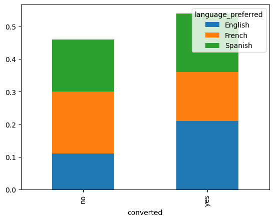

```python
#Plotting the contigency table using a stacked bar plot
plt.figure(figsize=(5,4))
pd.crosstab(df['converted'],df['language_preferred'],margins=False,normalize = True).plot(kind='bar',stacked ='True')
```

- Based on the stacked bar plot,overall converted users are higher than non-converted users.
- Number of users preferring Spanish language are almost the same in both converted(18 users) and non-converted users(16 users).
- Number of users converted (21 users) have a higher preference for English Language.
- Highest number of users (19 users) not converted preferred French language.

Formulating Null and Alternate Hypothesis

> $H_0$: conversion and preferred language are independent\ $H_a$: conversion and preferred language are dependent

Setting the level of significance (alpha) as 0.05

```python
from scipy.stats import chi2_contingency

chi,p_value,dof,expected = chi2_contingency(contingency_table)
print('The test-statistic value is:', chi)
print('The p_value is:', p_value)
print('The degrees of freedom are:', dof)
print('The expected frequencies are:', expected)
```

```
The test-statistic value is: 3.0930306905370837
The p_value is: 0.21298887487543447
The degrees of freedom are: 2
The expected frequencies are: [[14.72 15.64 15.64]
 [17.28 18.36 18.36]]
```

Based on the p_value of 0.212 above which is higher than the level of significance 0.05, we fail to reject the null hypothesis. We do not have enough evidence to conclude that conversion and preferred language are dependent on each other.

## 4. Is the time spent on the new page same for the different language users?

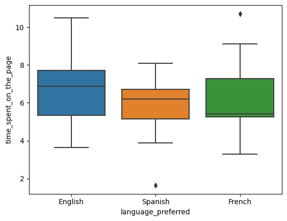

```python
#plotting a boxplot of different language users and time spent on the new page

sns.boxplot(x=df_new['language_preferred'],y=df_new['time_spent_on_the_page'])
```

In order to test if the mean time of different language users are the same on the new page, ANOVA test can be used.

Consider $\mu_1,\mu_2 and \mu_3$ as the mean time of English, French and Spanish language users spent on the new landing page, and hence the hypothesis is formulated as follows:

> $H_0$: Mean time spent on the new page is the same for all three language users\ $H_a$: At least one of the mean time of the three language users is different

or

> $H_0: \mu_1=\mu_2=\mu_3$\ $H_a: \mu_1\neq\mu_2$ or $\mu_2\neq\mu_3$ or $\mu_1\neq\mu_3$

Considering the level of significance at 5%

The following assumptions of ANOVA Test are also tested below:

For testing assumption of normality: Shapiro-Wilk’s test is applied to the response variable.  
For testing assumption of equality of variances: Levene's test applied to the response variable.

### Shapiro-Wilk’s test:

Formulating null and alternate hypothesis for Shapiro-Wilk's test -

> $H_0$: Time spent on the new landing page follows a normal distribution\ $H_a$: Time spent on thew new landing page does not follow a normal distribution

```python
#importing Shapiro from scipy.stats
from scipy.stats import shapiro

#performing the test to find p-value
test_statistic,p_value =shapiro(df_new['time_spent_on_the_page'])

print('The p_value of Shapiro-Wilk test is:',p_value)
```

```
The p_value of Shapiro-Wilk test is: 0.8040016293525696
```

Based on the p_value of 0.804 which is greater than the level of significance of 0.05, we fail to reject the null, and conclude that the time spent on the new landing page follows a normal distribution.

### Levene's Test:

Formulating null and alternate hypothesis for Levene's test -

> $H_0$: Variances of time spent by all different language users are equal\ $H_a$: Atleast one variance of the time spent by different language users are different

```python
#importing levene from scipy.stats
from scipy.stats import levene

#performing the test to find p-value
test_statistic, p_value = levene( df_new['time_spent_on_the_page'][df_new['language_preferred']=="English"],
                                   df_new['time_spent_on_the_page'][df_new['language_preferred']=="French"],
                                   df_new['time_spent_on_the_page'][df_new['language_preferred']=="Spanish"])

print('The p-value of levene test is', p_value)
```

```
The p-value of levene test is 0.46711357711340173
```

Based on the p_value of levene's test of 0.467 which is greater than the level of significance of 0.05, we fail to reject the null hypothesis and it can be concluded that the variances of time spent by all different language users are equal.

Based on the test of assumptions of ANOVA Test, the following assumptions are satisfied -

- The populations are normally distributed - Yes, the normality assumption is verified using the Shapiro-Wilk’s test.
- Population variances are equal - Yes, the homogeneity of variance assumption is verified using the Levene's test.
- Samples are independent simple random samples - Yes, we are informed that collected sample is a random sample.

### Performing ANOVA test:

```python
#importing f_oneway from scipy.stats
from scipy.stats import f_oneway

#performing the test to find p-value
test_statistic, p_value = f_oneway( df_new['time_spent_on_the_page'][df_new['language_preferred']=="English"],
                                   df_new['time_spent_on_the_page'][df_new['language_preferred']=="French"],
                                   df_new['time_spent_on_the_page'][df_new['language_preferred']=="Spanish"])

print('The p-value of f_oneway test is', p_value)
```

```
The p-value of f_oneway test is 0.43204138694325955
```

Based on the p_value of ANOVA test of 0.432 which is greater than the level of significant of 0.05, we fail to reject the null hypothesis. We do not have enough statistical evidence to conclude that the mean time spent by at least one of the English, French or Spanish language users is different.

## Conclusion and Business Recommendations

### Conclusions:

- From the above analysis, it can be concluded that E-news Express has been able to attract new subscribers/convert users basis the new landing page, and that the creation of this page proves to be effective for their business.
- There is enough statistical evidence to conclude that the mean time users spend on new landing page is more than old landing page.
- There is enough statistical evidence to conclude that the conversion rate of new landing page is greater than the conversion rate of the old landing page.
- Although conversion rate and language preferred are not dependent on each other, still the new landing page has significantly helped E-news Express to convert the French users which were higher in number for non-conversion on the old landing page.
- Conversion rate for the new landing page is higher for French (70%) and Spanish (64%) Language users followed by English language users (62%).
- Irrespective of the group, converted users spend an average time of 6.6 mins on the two landing pages.
- Overall, the average time spent by the treatment group has also improved and is much higher on the new landing page (6.2 mins).

### Recomendations:

- E-news Express can further gather data on the number of clicks, user location, news topics referred, news preferrences by users who spend more than 6 mins on an average on their landing page, since the sample data suggests that on an average all converted users spend about ~6.6 mins on the landing pages.
- Conversion rate for the new landing page is lowest for English language users (62%), E-news Express data science team could analyse why this is the case and can futher collect more information about the English language preferred users to improve their conversion rate.